# 2U challenge - part 2

Stefan Fouche

## Load and view first dataset

```r
library(tidyverse)
```

It seems as though the data is on an opportunity - person grain.

Each combination has a predicted enrollment probability and actual enrollment status (presumably at present?).

It’s not clear to me what the start date means but for now I will assume the start date refers to the first time an opportunity was outbound/communicated to a person.

```r
df_1 %>%
  group_by(opportunity_id,start_date) %>%
  tally %>%
  arrange(-n)
```

| opportunity_id | start_date | n |
| --- | --- | --- |
| 0061N00000aCe5ZQAS | 2018-08-20 | 2 |
| 0061N00000aFe3qQAC | 2018-08-29 | 2 |
| 0061N00000aP6YgQAK | 2018-09-04 | 2 |
| 0061N00000aPqnyQAC | 2018-09-06 | 2 |
| 0061N00000aPtXrQAK | 2018-09-06 | 2 |
| 0061N00000aR9KMQA0 | 2018-09-12 | 2 |
| 0061N00000b5slVQAQ | 2018-09-22 | 2 |
| 0061N00000b7ye1QAA | 2018-09-30 | 2 |
| 0061N00000blm14QAA | 2018-10-25 | 2 |
| 0061N00000bTZ4xQAG | 2018-10-03 | 2 |

[output cut: 990 more lines]

```r
df_1 %>%
  filter(opportunity_id == '0061N00000aCe5ZQAS')
```

| opportunity_id | person_code | course_code | start_date | enroll_status | predicted_enrollment |
| --- | --- | --- | --- | --- | --- |
| 0061N00000aCe5ZQAS | 1561 | 2742 | 2018-08-20 | (null) | 0.009175288405 |
| 0061N00000aCe5ZQAS | 1561 | 2742 | 2018-08-20 | (null) | 0.009175288405 |

First example case was a duplicate????? Why are there duplicates?

### Dedup the data

The data had dimensions 2182, 6

If we remove duplicates we have dimensions;

```r
df_1 %>%
  unique() %>%
  dim
```

```
[1] 2003    6
```

We will remove all duplicates

```r
df_1 = df_1 %>% unique()
```

Let’s confirm opportunity - start date counts

```r
df_1 %>%
  group_by(opportunity_id,start_date) %>%
  tally %>%
  arrange(-n)
```

| opportunity_id | start_date | n |
| --- | --- | --- |
| 0061N00000YQ3QmQAL | 2018-05-10 | 2 |
| 0061N00000YqNpcQAF | 2017-05-20 | 2 |
| 0061N00000YsmwvQAB | 2018-01-03 | 2 |
| 0061N00000aBmn1QAC | 2018-08-17 | 1 |
| 0061N00000aBtq8QAC | 2018-08-17 | 1 |
| 0061N00000aCCb5QAG | 2018-08-18 | 1 |
| 0061N00000aCccfQAC | 2018-08-20 | 1 |
| 0061N00000aCe5ZQAS | 2018-08-20 | 1 |
| 0061N00000aCJzpQAG | 2018-08-19 | 1 |
| 0061N00000aCLIEQA4 | 2018-08-19 | 1 |

[output cut: 990 more lines]

First case

```r
df_1 %>%
  filter(opportunity_id == '0061N00000YQ3QmQAL')
```

| opportunity_id | person_code | course_code | start_date | enroll_status | predicted_enrollment |
| --- | --- | --- | --- | --- | --- |
| 0061N00000YQ3QmQAL | 1573 | 2706 | 2018-05-10 | Enrolled | 0.00583010969 |
| 0061N00000YQ3QmQAL | 1573 | 2706 | 2018-05-10 | enrolled | 0.00583010969 |

:(

### Find and replace duplicate categorical features

```r
df_1 %>%
  group_by(enroll_status) %>%
  summarise %>%
  arrange(enroll_status)
```

| enroll_status |
| --- |
| (null) |
| enrolled |
| Enrolled |

```r
df_1 =
  df_1 %>%
  mutate(enroll_status = if_else(enroll_status == 'Enrolled','enrolled',enroll_status))
```

Check opportunity - start date parity

```r
df_1 = df_1 %>% unique()

df_1 %>%
  group_by(opportunity_id,start_date) %>%
  tally %>%
  arrange(-n)
```

| opportunity_id | start_date | n |
| --- | --- | --- |
| 0061N00000aBmn1QAC | 2018-08-17 | 1 |
| 0061N00000aBtq8QAC | 2018-08-17 | 1 |
| 0061N00000aCCb5QAG | 2018-08-18 | 1 |
| 0061N00000aCccfQAC | 2018-08-20 | 1 |
| 0061N00000aCe5ZQAS | 2018-08-20 | 1 |
| 0061N00000aCJzpQAG | 2018-08-19 | 1 |
| 0061N00000aCLIEQA4 | 2018-08-19 | 1 |
| 0061N00000aCOFDQA4 | 2018-08-19 | 1 |
| 0061N00000aCrCwQAK | 2018-08-20 | 1 |
| 0061N00000aCZgUQAW | 2018-08-20 | 1 |

[output cut: 990 more lines]

Store cleaning steps for our data pipeline (should we need to model later)

```r
clean_data =
  . %>%
  mutate(enroll_status = if_else(enroll_status == 'Enrolled','enrolled',enroll_status)) %>%
  unique() %>%
  mutate(predicted_enrollment = as.numeric(predicted_enrollment))
```

## Data wrangling

```r
df_1 = data.table::fread("../data/raw/Data Science SAE data - dataset 1.csv")

df_1 =
  df_1 %>%
  clean_data
```

```
NAs introduced by coercion
```

```r
df_1
```

| opportunity_id | person_code | course_code | start_date | enroll_status | predicted_enrollment |
| --- | --- | --- | --- | --- | --- |
| 0061N00000ZjzbLQAR | 7 | 2753 | 2018-08-12 | (null) | 0.004737075 |
| 0061N00000ZJmESQA1 | 11 | 2802 | 2018-07-11 | enrolled | 0.007800197 |
| 0061N00000dvqlCQAQ | 11 | 2773 | 2019-01-19 | (null) | 0.013787269 |
| 0061N00000YRJAAQA5 | 11 | 2593 | 2018-02-17 | enrolled | 0.002708092 |
| 0061N00000YsoJLQAZ | 11 | 2587 | 2018-01-26 | enrolled | 0.105583756 |
| 0061N00000Ys9lJQAR | 11 | 2391 | 2018-02-17 | (null) | 0.163170538 |
| 0061N00000YPz88QAD | 11 | 2599 | 2018-02-17 | enrolled | 0.007800197 |
| 0061N00000Ys1QHQAZ | 11 | 2233 | 2018-02-02 | (null) | 0.022217771 |
| 0061N00000Ys2dNQAR | 20 | 2431 | 2018-02-06 | (null) | 0.233270887 |
| 0061N00000Ysh7BQAR | 30 | 2127 | 2017-08-30 | enrolled | 0.517594325 |

[output cut: 990 more lines]

### First opportunity enrollments

We will assume first opportunity refers to the first outbount for a given person…

Let’s see how many oppertunities people recieve

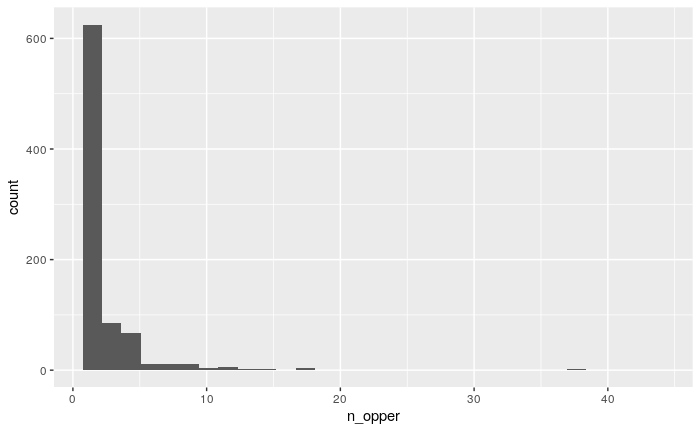

```r
df_1 %>%
  group_by(person_code) %>%
  summarise(n_opper = n_distinct(opportunity_id)) %>%
  ggplot()+
  geom_histogram(aes(x=n_opper))
```

Some people recieve a lot of offers!

Most people recieve between 1 and 5 opportunities.

Let’s see how many people enrol the first time an outbound message is recieved

```r
df_1 %>%
  group_by(person_code) %>%
  filter(start_date == min(start_date)) %>%
  ungroup %>%
  group_by(enroll_status) %>%
  tally %>%
  mutate(percentage = n/sum(n))
```

| enroll_status | n | percentage |
| --- | --- | --- |
| (null) | 843 | 0.8489426 |
| enrolled | 150 | 0.1510574 |

### Time between first enrollment and interest in next course

The question is worded in a way that makes me think each `opportunity_id` is recorded due to a user interaction asking for information about an oppertunity.

I will assume this is true and measure the time between first enrollment and the next oppertunity regardless of enrollment

This is as easy as sorting each person on time, taking the lag and returning the date difference of the first interaction

```r
time_to_next =
  df_1 %>%
  mutate_if(names(df_1) %>% grepl(pattern = "date"),as.Date) %>%
  arrange(start_date) %>%
  group_by(person_code) %>%
  mutate(lead_start_date = lead(start_date)) %>%
  left_join(df_1 %>%
              group_by(person_code) %>%
              filter(enroll_status == 'enrolled') %>%
              summarise(first_enrol_date = min(start_date)) %>%
              select(person_code,first_enrol_date)
            ) %>%
  filter(start_date == first_enrol_date) %>%
  transmute(time_to_next_opportunity = lead_start_date - start_date)
time_to_next
```

| person_code | time_to_next_opportunity |
| --- | --- |
| 3248 | 72 days |
| 3039 | 64 days |
| 494 | 33 days |
| 4911 | 132 days |
| 3877 | 29 days |
| 5441 | NA days |
| 1760 | 58 days |
| 2867 | 49 days |
| 2909 | 65 days |
| 3048 | 0 days |

[output cut: 270 more lines]

So on average;

```r
time_to_next %>%
  ungroup %>%
  summarise(mean(time_to_next_opportunity,na.rm = T))
```

| mean(time_to_next_opportunity, na.rm = T) |
| --- |
| 95.26415 days |

Interesting…

Is there a monthly/weekly cycle?

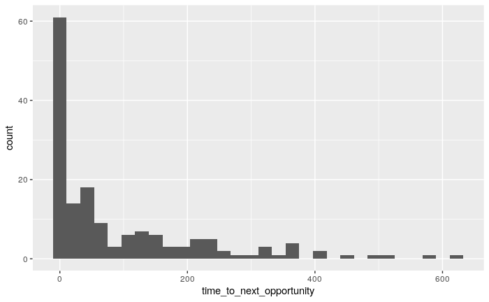

```r
time_to_next %>%
  ggplot()+
  geom_histogram(aes(x = time_to_next_opportunity))
```

Nevermind!

### Let’s try to visualize model accuracy

We can start by visualizing raw predictions with a confusion matrix.

We will assume that the model was calibrated to predict enrollment if probability is over %50 (which might not be true depending on how the model was calibrated for precision recall)

```r
df_1 %>%
  mutate(predicted = round(predicted_enrollment)) %>%
  select(enroll_status,predicted) %>%
  table
```

```
             predicted
enroll_status    0    1
     (null)   1663    3
     enrolled  326    7
```

Hmmm!?

Let’s look at the model prediction density

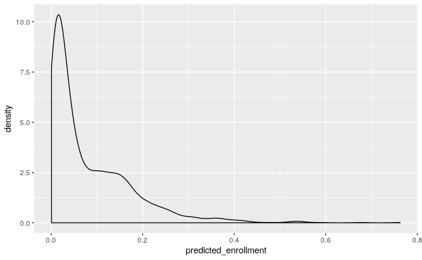

```r
df_1 %>%
  ggplot()+
  geom_density(aes(x=predicted_enrollment))
```

Let’s calculate some performance metrics!?

```r
library(yardstick)
metric_data =
  df_1 %>%
  mutate(predicted = round(predicted_enrollment)) %>%
  select(enroll_status,predicted,predicted_enrollment) %>%
  mutate(enroll_status = if_else(enroll_status == 'enrolled', 1, 0)) %>%
  mutate(enroll_status = as.factor(enroll_status)) %>%
  mutate(predicted = as.factor(predicted))

metric_data %>%
  metrics(enroll_status, predicted) %>%
  bind_rows(
  metric_data %>%
  roc_auc(enroll_status, predicted_enrollment)
  )
```

| .metric | .estimator | .estimate |
| --- | --- | --- |
| accuracy | binary | 0.83541771 |
| kap | binary | 0.03140809 |
| roc_auc | binary | 0.59847182 |

```r
NA
NA
```

We may also want to see if the calibration of the model at least ranks…

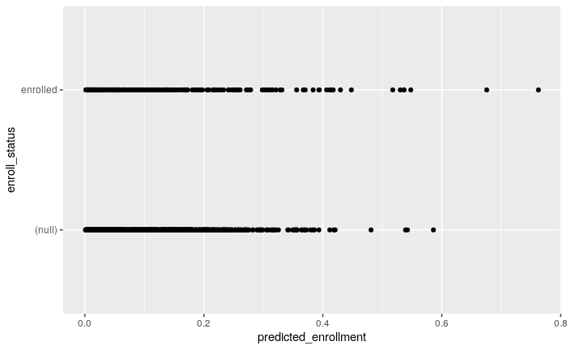

```r
df_1 %>%
  ggplot()+
  geom_point(aes(x=predicted_enrollment,y=enroll_status))
```

That doesn’t look like it ranks :(

We can do a statistical test for rigour

```r
enrol_groups =
  df_1 %>%
  select(opportunity_id,enroll_status,predicted_enrollment) %>%
  spread(key = enroll_status,value = predicted_enrollment)

ks.test(enrol_groups %>% pull(enrolled) %>% purrr::discard(is.na),enrol_groups %>% pull(`(null)`) %>% purrr::discard(is.na))
```

```
p-value will be approximate in the presence of ties
```

```
    Two-sample Kolmogorov-Smirnov test

data:  enrol_groups %>% pull(enrolled) %>% purrr::discard(is.na) and enrol_groups %>% pull(`(null)`) %>% purrr::discard(is.na)
D = 0.19375, p-value = 1.784e-09
alternative hypothesis: two-sided
```

Well, at least the 2 ditributions are different (so the model appears to be better than random)

## Part 2

### Use twitter api

Load twitter users

```r
library(reticulate)
```

```python
import pandas as pd
import numpy as np
import time
import twython
from twython import Twython
import json
import re
```

```python
people = pd.read_csv("../data/raw/Data Science SAE data - dataset 2.csv")
```

```r
py$people
```

| twitter usernames: |
| --- |
| @Trevornoah |
| @media24  |
| @getsmarter  |
| @2Uinc  |
| @ClubCricketSA  |

We want to collect tweets for these users…

Someone thought it would be funny to add whitespace characters to the data :(  
It wasn’t funny

```python
# Load credentials from json file
with open("../twitter_credentials.json", "r") as file:
    creds = json.load(file)
```

```python
python_tweets = Twython(creds['CONSUMER_KEY'], creds['CONSUMER_SECRET'])
```

```python
def get_user_data(tw_name,tw_api):
    try:
        print('getting data for {}'.format(tw_name))
        tw_name = re.sub('[^\w\s]', '', tw_name)
        tw_data = tw_api.show_user(screen_name=tw_name)
    except Exception as e:
        print(e)
        return(None)
    else:
        return(tw_data)
```

[output not shown]

Saving to csv

```python
df.to_csv("../data/processed/twitter.csv")
```

### How can we use twitter data

Twitter is great source for data.

We can use twitter to find potential leads by looking for users following/retweating/commenting on posts/people related to a course or opportunity we want to promote.

We can analyse the tweets of prospective users using for example transformer networks to predict if a user will enroll/pass

We can create graphs of prospective or past customers to predict using for example convolutional graph neural networks if related/connected users would enroll

etc.